# Project 2: Wrangling and Exploratory Data Analysis

### Expected wins

#### Problem 7

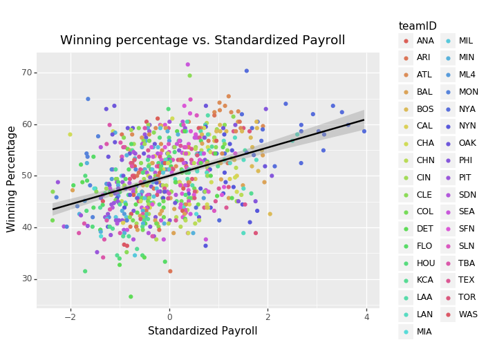

```python
# We make a single scatter plot where the x-axis is the standardized payroll and y-axis is the winning percentage
# Then we generate the regression line to see how are the two attributes correlated.
df_p7 = df[['standardized_payroll', 'winRate', 'teamID']]
p = (ggplot(df_p7, aes(x='standardized_payroll', y='winRate')) +
     geom_point(aes(color='teamID')) +
     geom_smooth(method='lm') +
     labs(y="Winning Percentage", x = "Standardized Payroll")  +
     ggtitle('Winning percentage vs. Standardized Payroll')
)

p
```

### Spending efficiency

#### Problem 8

```python
# We create a new column called 'effeciency to store the calculated effeciency of a  team in a certain year'
expected_win_pct = lambda std_payroll: 50 + 2.5 * std_payroll
df['efficiency'] = df['winRate'] - df['standardized_payroll'].map(expected_win_pct)

df.head(3)
```

|  | yearID | teamID | lgID | playerID | franchID | W | G | payroll | winRate | binned | standardized_payroll | efficiency |
| --- | --- | --- | --- | --- | --- | --- | --- | --- | --- | --- | --- | --- |
| 0 | 2001 | SEA | AL | abbotpa01 | SEA | 116 | 162 | 74720834.0 | 71.604938 | 2000-2004 | 0.379047 | 20.657320 |
| 1 | 1998 | NYA | AL | bankswi01 | NYY | 114 | 162 | 66806867.0 | 70.370370 | 1995-1999 | 1.573223 | 16.437314 |
| 2 | 1995 | CLE | AL | alomasa02 | CLE | 100 | 144 | 37937835.0 | 69.444444 | 1995-1999 | 0.418796 | 18.397454 |

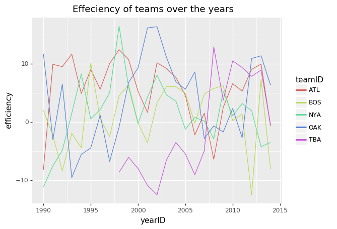

```python
# We use geom_line instead of geom_smooth to have a more precise observation of the effeciency of every team in a year.
# We choose the following 5 teams to see how good is their effeciency over the years.
df_p8 = df[df['teamID'].isin(['OAK', 'BOS', 'NYA', 'ATL', 'TBA'])][['yearID', 'teamID', 'efficiency']]

p = (ggplot(df_p8, aes(x='yearID', y='efficiency')) +
     geom_line(aes(color = 'teamID')) +
     ggtitle('Effeciency of teams over the years')
)

p
```

#### Question 4

The above plot a teams effeciency over the years. It explicitly shows how good a team performs given their total payroll. Basically, every team aims to perform as good as possible with a fixed amount of money, and the "effeciency" we defined help us to quantify it. By comparing the above plot with the ones in Question2 and Question3, we can see that teams with possible effeciency are typically those which lies above the regression line in the plot of Question2 and Question3. During the Moneyball period, Oakland's effeciency is roughly 16-17 as we can tell from the plot.